# TransistorConfiguraties slides

Transistor Configuraties

Jan Genoe

Februari 2026

###### Tweepoort configuratie

## Tweepoort configuratie

###### 3-terminal configuratie: spanningen

[figure not shown]

###### 3-terminal configuratie: stromen

[figure not shown]

###### 3-terminal configuratie: transconductantie

[figure not shown]

###### 2 terminal configuratie

[figure not shown]

###### MOS transistor configuraties

## MOS transistor configuraties

###### De MOS transistor geschakeld als 2-terminal component

- De MOS transistor geschakeld als diode
- De MOS transistor geschakeld als actieve belasting

###### nMOS transistor als diode geschakeld

[figure not shown]

###### nMOS transistor Stroomspiegel

[figure not shown]

We merken op dat in {numref}`stroomspiegel` enkel de inputtransistor als diode geschakeld is. De uitgangstransistor is actief als een transconductantie.

Zowel pMOS als nMOS transistors kunnen als diode geschakeld worden (zie {numref}`Tdiodep`. We merken hierbij wel op dat er voor het schema met de pMOS enkel stroom loopt als $V_{in} -V_s < V_T$ terwijl het voor het schema voor de nMOS transistor juist omgekeerd is.

###### pMOS en nMOS transistor als diode

[figure not shown]

###### pMOS en nMOS stroomspiegels

[figure not shown]

#### De MOS transistor als actieve belasting

###### pMOS als actieve belasting

[figure not shown]

###### pMOS als actieve belasting

[figure not shown]

###### De MOS transistor geschakeld als 3-terminal component

- gemeenschappelijke source
  - de ingang is dan verbonden met de gate (=spanningsbron )
  - de uitgang is dan verbonden met de drain
  - deze transistor werkt als een spanningsversterker (amplifier)
- gemeenschappelijke drain
  - de ingang is dan verbonden met de gate (=spanningsbron)
  - de uitgang is dan verbonden met de source
  - de spanning aan de source volgt de spanning aan de ingang (source follower)
- gemeenschappelijke gate
  - de ingang is dan verbonden met de source (stroombron)
  - de uitgang is dan verbonden met de drain
  - de spanning aan de drain wordt bepaald door de stroom aan drain (cascode trap)

###### Gemeenschappelijke Source Schakeling

[figure not shown]

###### Gemeenschappelijke Source Schakeling

[figure not shown]

###### nMOS transistor in een gemeenschappelijke source schakeling

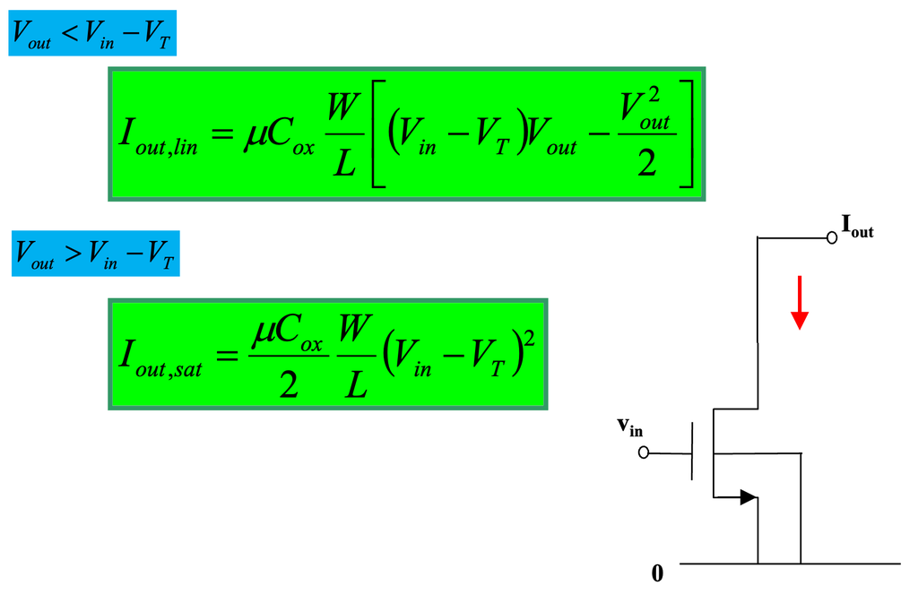

###### nMOS transistor in een gemeenschappelijke source schakeling

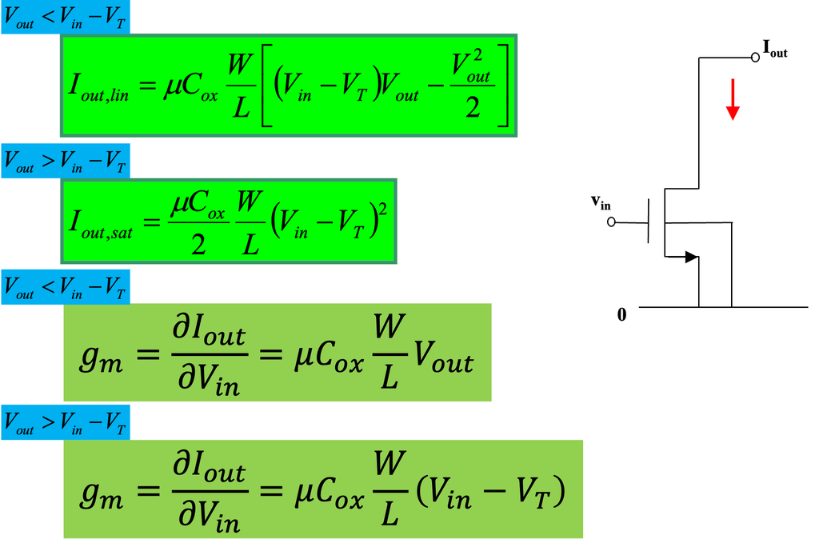

###### nMOS transistor in een gemeenschappelijke source schakeling

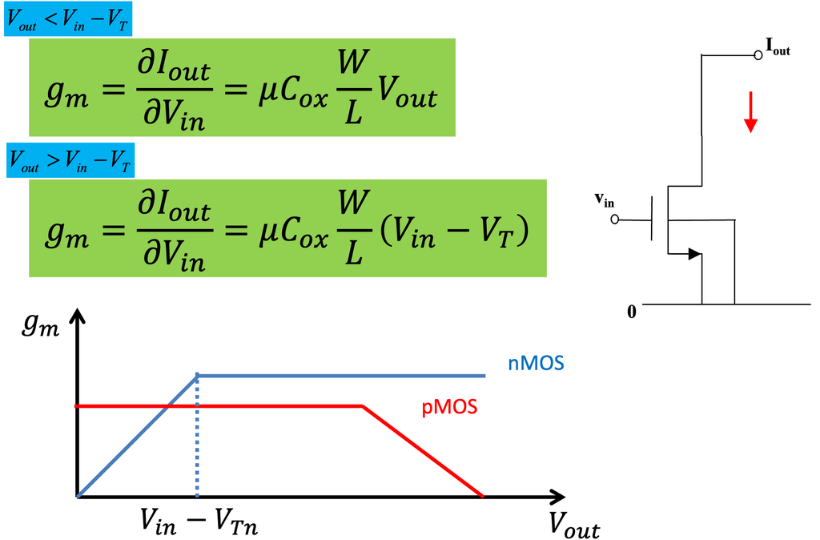

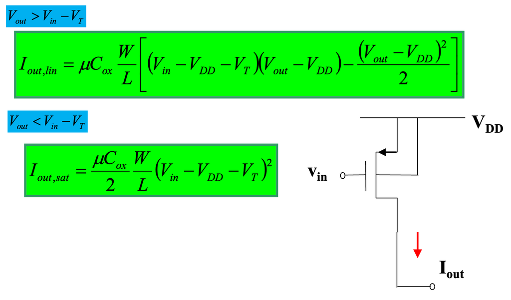

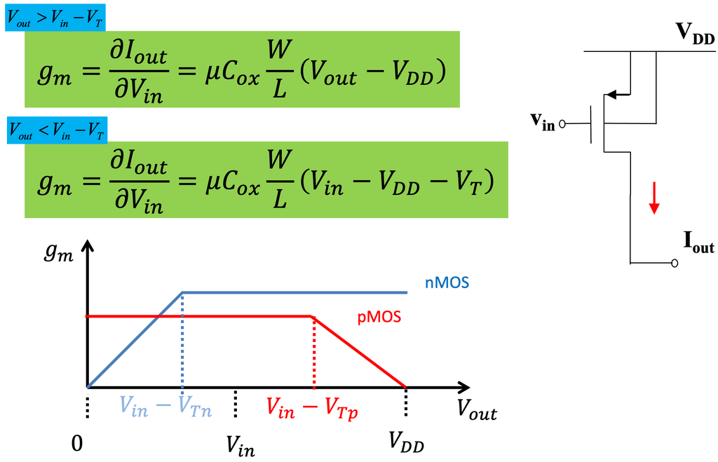

###### nMOS transistor in een gemeenschappelijke source schakeling

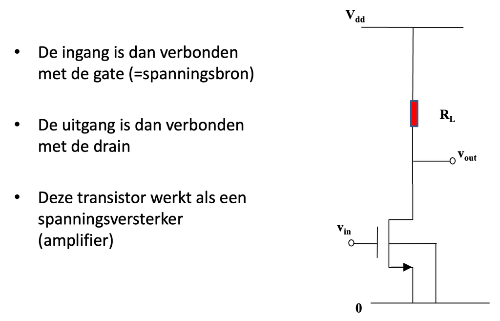

###### nMOS transistor in een gemeenschappelijke source schakeling

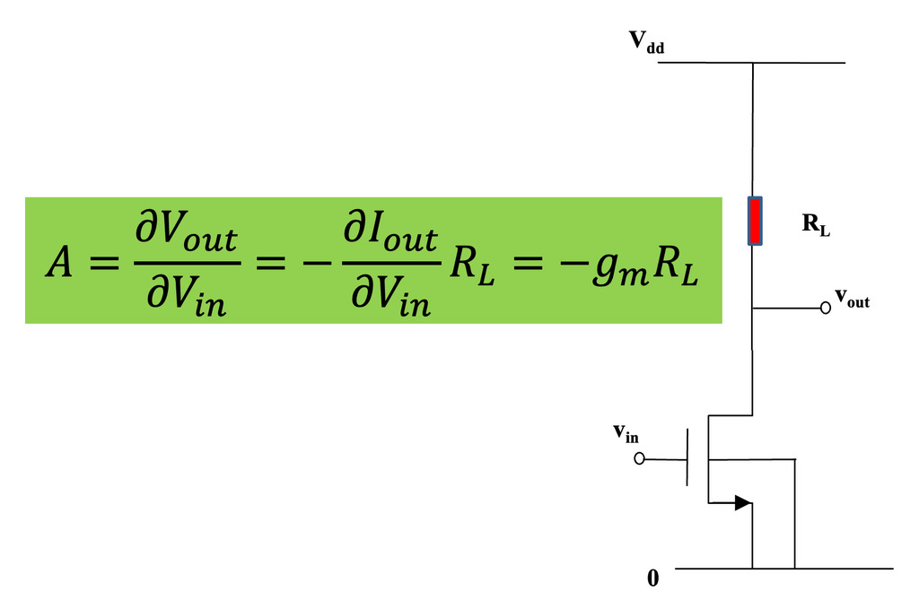

###### nMOS transistor in een gemeenschappelijke source schakeling

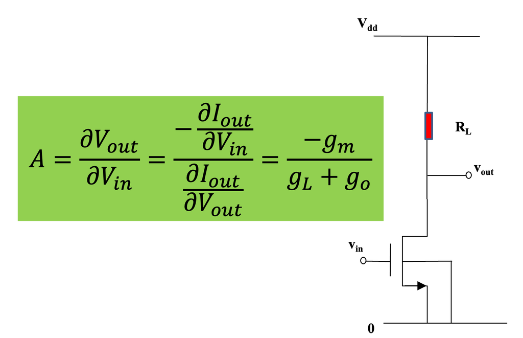

###### nMOS transistor in een gemeenschappelijke source schakeling

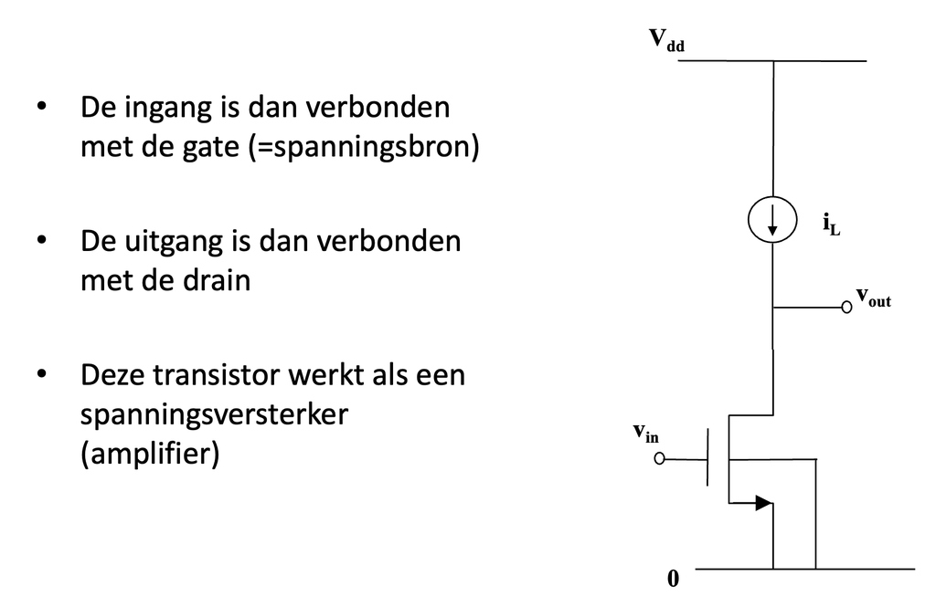

###### nMOS transistor in een gemeenschappelijke source schakeling

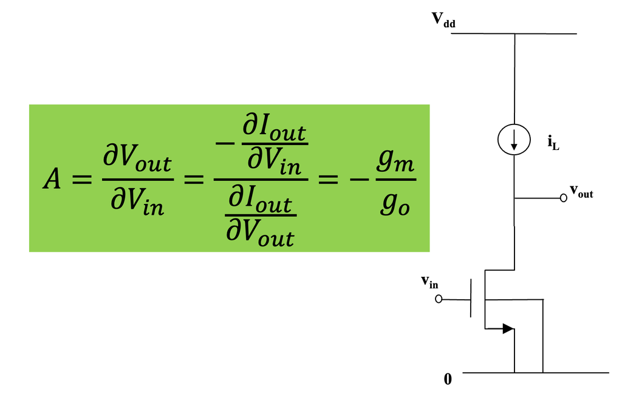

###### nMOS transistor in een gemeenschappelijke drain schakeling

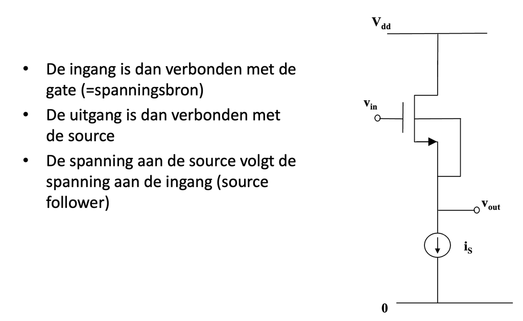

###### nMOS transistor in een gemeenschappelijke drain schakeling

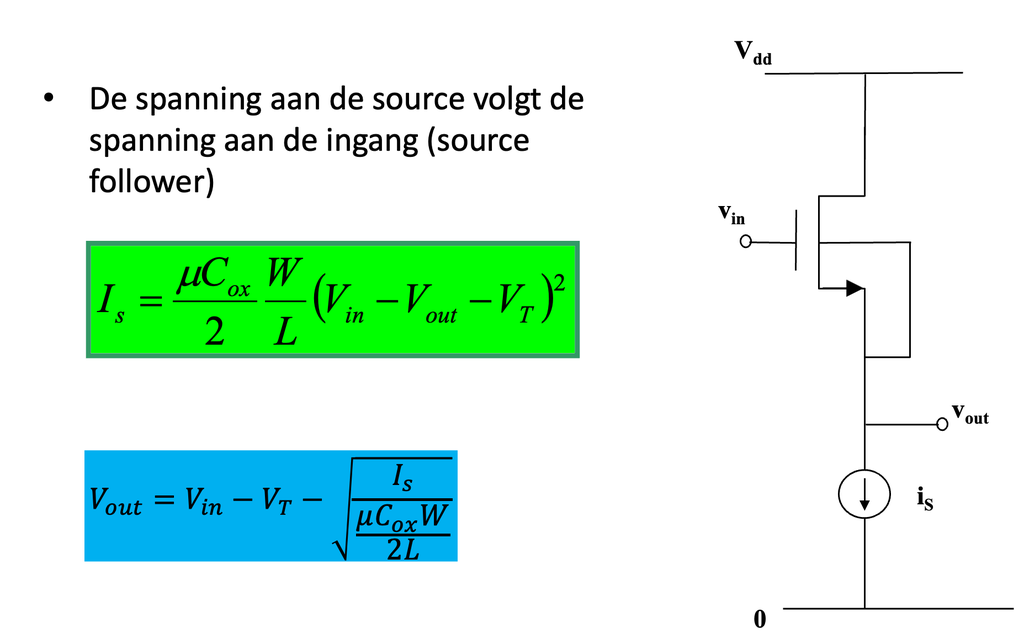

###### nMOS transistor in een gemeenschappelijke gate schakeling

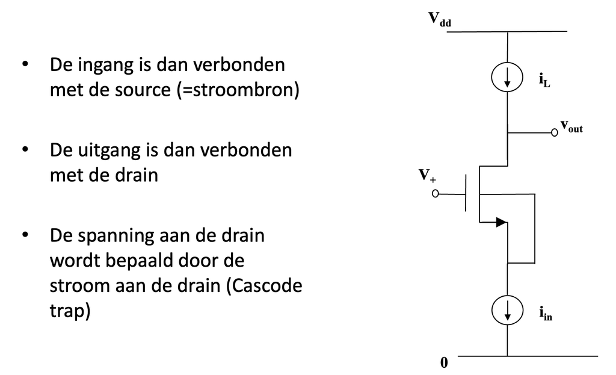

###### Bipolaire transistor configuraties

## Bipolaire transistor configuraties

###### De bipolaire transistor geschakeld als 3-terminal component

- Gemeenschappelijke emitter
  - de ingang is dan verbonden met de basis
  - de uitgang is dan verbonden met de collector
  - deze transistor werkt als een versterker (amplifier)
- Gemeenschappelijke collector
  - de ingang is dan verbonden met de basis
  - de uitgang is dan verbonden met de emitter
  - de spanning aan de emitter volgt de spanning aan de basis (emitter follower)
- Gemeenschappelijke basis
  - de ingang is dan verbonden met de emitter
  - de uitgang is dan verbonden met de collector
  - de spanning aan de collector wordt bepaald door de stroom aan collector (cascode trap)

###### npn transistor in een gemeenschappelijke emitter schakeling

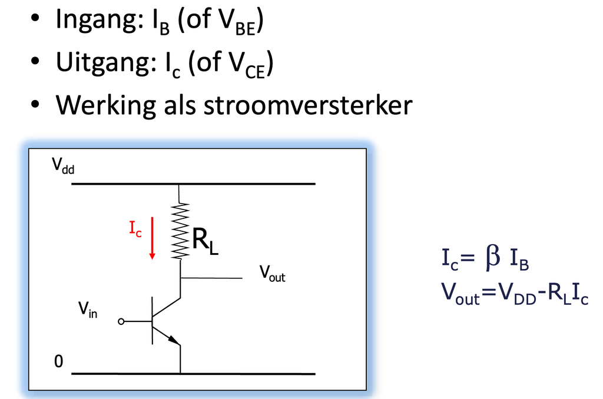

###### npn transistor in de Gemeenschappelijke Emitter Schakeling

[figure not shown]

###### npn transistor in de Gemeenschappelijke Emitter Schakeling

[figure not shown]

###### npn transistor in de Gemeenschappelijke Emitter Schakeling

[figure not shown]

###### npn transistor in een gemeenschappelijke collector schakeling

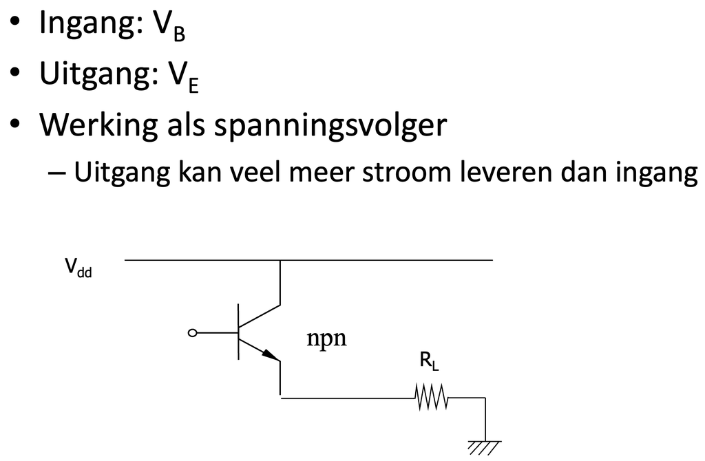

###### npn transistor in een gemeenschappelijke basis schakeling

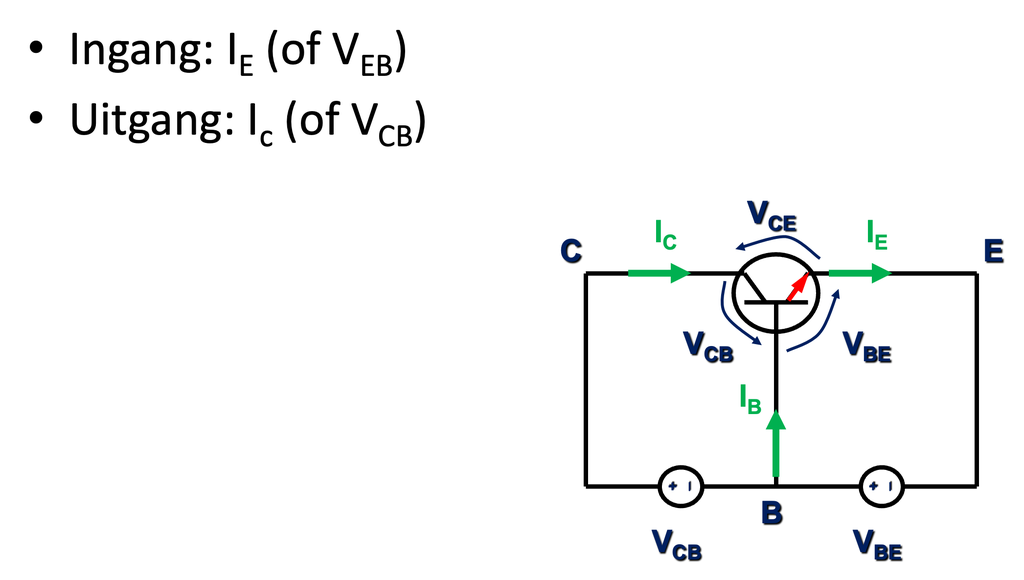

I would rather have questions that can't be answered  
than answers that can't be questioned.

Richard Feynman